# Pitcher Deception Index

```python
from pybaseball import statcast_pitcher

def getPitcherStats(year, id):
    start_date = f"{year}-4-01"
    end_date = f"{year}-11-1"
    data = statcast_pitcher(start_date,end_date, player_id=id)
    return data
pitcher_data = getPitcherStats(2025,663893)
pitcher_data.head(1)
```

```
Gathering Player Data
```

|  | pitch_type | game_date | release_speed | release_pos_x | release_pos_z | player_name | batter | pitcher | events | description | ... | batter_days_until_next_game | api_break_z_with_gravity | api_break_x_arm | api_break_x_batter_in | arm_angle | attack_angle | attack_direction | swing_path_tilt | intercept_ball_minus_batter_pos_x_inches | intercept_ball_minus_batter_pos_y_inches |
| --- | --- | --- | --- | --- | --- | --- | --- | --- | --- | --- | --- | --- | --- | --- | --- | --- | --- | --- | --- | --- | --- |
| 0 | SI | 2025-09-26 | 94.0 | 2.29 | 5.82 | Little, Brendon | 666624 | 663893 | field_out | hit_into_play | ... | NaN | 2.48 | 1.22 | -1.22 | 32.1 | 5.565162 | 4.953149 | 26.448714 | 40.855266 | 27.512562 |

1 rows × 118 columns

```python
import pandas as pd
# Display all columns
pd.options.display.max_columns = None
pitcher_data.head(
2
)
```

|  | pitch_type | game_date | release_speed | release_pos_x | release_pos_z | player_name | batter | pitcher | events | description | spin_dir | spin_rate_deprecated | break_angle_deprecated | break_length_deprecated | zone | des | game_type | stand | p_throws | home_team | away_team | type | hit_location | bb_type | balls | strikes | game_year | pfx_x | pfx_z | … |
| --- | --- | --- | --- | --- | --- | --- | --- | --- | --- | --- | --- | --- | --- | --- | --- | --- | --- | --- | --- | --- | --- | --- | --- | --- | --- | --- | --- | --- | --- | --- |
| 0 | SI | 2025-09-26 | 94.0 | 2.29 | 5.82 | Little, Brendon | 666624 | 663893 | field_out | hit_into_play | NaN | NaN | NaN | NaN | 9 | Christopher Morel flies out to right fielder N... | R | R | L | TOR | TB | X | 9.0 | fly_ball | 2 | 1 | 2025 | 1.22 | 0.09 | … |
| 1 | KC | 2025-09-26 | 87.1 | 1.67 | 6.11 | Little, Brendon | 666624 | 663893 | NaN | blocked_ball | NaN | NaN | NaN | NaN | 13 | Christopher Morel flies out to right fielder N... | R | R | L | TOR | TB | B | NaN | NaN | 1 | 1 | 2025 | -0.08 | -0.90 | … |

```python
pitcher_data['pitch_type'].value_counts()
```

```
pitch_type
KC    551
SI    537
FC     86
FF      6
Name: count, dtype: int64
```

## Data Selection

Given the values we have here let's work with the following metrics to develop this statistic:

1. x,y,z pitch release position
2. released spin rate
3. release arm extension
4. Target variable pitch type

```python
target_vars = [
    'release_pos_x', 'release_pos_z', 'release_pos_y',  'release_spin_rate','release_extension','pitch_type'
]
```

```python
# get and clean the data
df = pitcher_data[target_vars].dropna()
df.head()
```

|  | release_pos_x | release_pos_z | release_pos_y | release_spin_rate | release_extension | pitch_type |
| --- | --- | --- | --- | --- | --- | --- |
| 0 | 2.29 | 5.82 | 54.74 | 2175 | 5.8 | SI |
| 1 | 1.67 | 6.11 | 54.68 | 1661 | 5.8 | KC |
| 2 | 1.76 | 6.10 | 54.50 | 1708 | 6.0 | KC |
| 3 | 2.18 | 5.83 | 54.86 | 2155 | 5.6 | SI |
| 4 | 1.50 | 6.12 | 54.54 | 1567 | 6.0 | KC |

```python
# define a function to do all of the above for any pitcher and year
def getAndPreProcess(year, id):
    target_vars = [
    'release_pos_x', 'release_pos_z', 'release_pos_y','release_spin_rate', 'release_spin_rate','release_extension','pitch_type'
    ]
    pitcher_data = getPitcherStats(year, id)
    df = pitcher_data[target_vars].dropna()
    return df
```

```python
#group by pitch type
import pandas as pd
# let's make some functions to look at general variance in pitch profiles
def compute_medians(df: pd.DataFrame) -> pd.DataFrame:
    """
    Compute medians of release variables grouped by pitch_type.
    """
    cols = ['release_pos_x','release_pos_z','release_pos_y',
            'release_spin_rate','release_extension']
    return df.groupby('pitch_type')[cols].median().reset_index()

def compute_variances(df: pd.DataFrame) -> pd.DataFrame:
    """
    Compute variances of release variables grouped by pitch_type.
    """
    cols = ['release_pos_x','release_pos_z','release_pos_y',
            'release_spin_rate','release_extension']
    return df.groupby('pitch_type')[cols].var().reset_index()

def compute_summary(df: pd.DataFrame) -> pd.DataFrame:
    """
    Combine medians and variances into one summary table.
    """
    med = compute_medians(df)
    var = compute_variances(df)

    # merge on pitch_type
    summary = pd.merge(med, var, on="pitch_type", suffixes=("_median", "_var"))
    return summary

summary = compute_summary(df)
summary
```

|  | pitch_type | release_pos_x_median | release_pos_z_median | release_pos_y_median | release_spin_rate_median | release_extension_median | release_pos_x_var | release_pos_z_var | release_pos_y_var | release_spin_rate_var | release_extension_var |
| --- | --- | --- | --- | --- | --- | --- | --- | --- | --- | --- | --- |
| 0 | FC | 2.025 | 6.14 | 54.840 | 2207.0 | 5.70 | 0.012100 | 0.007479 | 0.016555 | 13121.563338 | 0.017566 |
| 1 | FF | 2.060 | 5.96 | 54.935 | 2020.0 | 5.55 | 0.016827 | 0.019910 | 0.011150 | 11290.166667 | 0.011000 |
| 2 | KC | 1.750 | 6.20 | 54.780 | 1816.0 | 5.70 | 0.011295 | 0.006343 | 0.019064 | 48115.341726 | 0.020462 |
| 3 | SI | 2.030 | 5.86 | 54.940 | 2026.0 | 5.60 | 0.015304 | 0.006977 | 0.020482 | 9559.167751 | 0.021357 |

# Implementation

Now let's use a Random Forest classifier to compute deception score.

We will implement cross-validation to get a robust estimate of accuracy, and ensure that our estimate will likely generalize to new data.

To account for a varying number of pitches thrown by a given pitcher, we normalize using the following set pf formulas:

### Defining our variables as:

- **Features:** $X \in \mathbb{R}^{n \times d}$
- **Labels:** $y \in \{1,2,\dots, C\}^n$ (with $C$ pitch types)

### Using the corss validation accuracy score:

$$ \text{acc} = \frac{1}{K} \sum_{k=1}^{K} \frac{1}{|D_k|} \sum_{(x_i,y_i) \in D_k} \mathbf{1}\{f_{-k}(x_i) = y_i\} $$

where:

- $K = 5$ folds
- $D_k$ = held-out fold
- $f_{-k}$ = classifier trained without fold $k$

### Calcualte a baseline model accuracy

$$ \text{baseline} = \frac{1}{C} $$

### Normalize it on the size of the set of possible pitches

$$ \text{norm\_acc} = \frac{\text{acc} - \text{baseline}}{1 - \text{baseline}} $$

### Calculate our final Deception score

$$ \text{deception} = 100 \times \Big(1 - \text{norm\_acc}\Big) $$

```python
from sklearn.model_selection import cross_val_score
from sklearn.ensemble import RandomForestClassifier
import numpy as np


def deception_score(df):
    cols = ['release_pos_x','release_pos_z','release_pos_y',
            'release_spin_rate','release_extension']

    X = df[cols]
    y = df['pitch_type']

    n_classes = y.nunique()
    if n_classes < 2:
        return np.nan  # can't compute with only one pitch type

    # let's use a relatively large forest to get a stable estimate
    clf = RandomForestClassifier(n_estimators=200, random_state=42)
    acc = cross_val_score(clf, X, y, cv=5, scoring="accuracy").mean()

    # normalize relative to random baseline
    baseline = 1 / n_classes
    norm_acc = (acc - baseline) / (1 - baseline)

    deception = 100 * (1 - norm_acc)
    return deception


score = deception_score(df)
score
```

```
np.float64(5.197740112994342)
```

This is good, but completly meaningless. Let's apply it to a larger number of pitchers so we can compare.

```python
# let's get all of the

def getTeamPitchingLog(start_date,end_date,team):
    from pybaseball import statcast
    import pandas as pd

    # Full 2025 regular season window (adjust as needed)
    df = statcast(start_dt=start_date, end_dt=end_date, team=team)
    return df

pitcher_data = getTeamPitchingLog("2025-8-01","2025-09-01","TOR")
```

```
This is a large query, it may take a moment to complete
```

[output not shown]

```python
player_ids = pitcher_data['pitcher'].unique()
# check that we have a good number of pitchers
player_ids
```

```
<IntegerArray>
[663893, 667297, 684320, 605135, 656546, 622554, 686973, 453286, 592332,
 677865, 669456, 641778, 687606, 689254, 621244, 680755, 623168]
Length: 17, dtype: Int64
```

```python
#get pitcher id, pitcher name pairs
pitcher_info = pitcher_data[['player_name', 'pitcher']].drop_duplicates()
pitcher_info.head(1)
```

|  | player_name | pitcher |
| --- | --- | --- |
| 127 | Little, Brendon | 663893 |

```python
# calculate and store deception scores for all pitchers in the dataset, a bit slow due to api calls for data collection, could improve with bulk loading at the start.
result = {}

for p in player_ids:
    print(p)
    df = getAndPreProcess(2025,p)
    if len(df) < 50:
        continue
    score = deception_score(df)
    result[p] = score
```

```
663893
Gathering Player Data
667297
Gathering Player Data
684320
Gathering Player Data
```

```
605135
Gathering Player Data
656546
Gathering Player Data
```

```
622554
Gathering Player Data
```

```
686973
Gathering Player Data
453286
Gathering Player Data
592332
Gathering Player Data
```

```
677865
Gathering Player Data
669456
Gathering Player Data
641778
Gathering Player Data
```

```
687606
Gathering Player Data
```

```
689254
Gathering Player Data
```

```
621244
Gathering Player Data
680755
Gathering Player Data
```

```
623168
Gathering Player Data
```

```python
#align pitcher_info with result
deception_df = pd.DataFrame(list(result.items()), columns=['pitcher', 'deception_score'])
deception_df = deception_df.merge(pitcher_info, on='pitcher')
```

```python
deception_df
```

|  | pitcher | deception_score | player_name |
| --- | --- | --- | --- |
| 0 | 663893 | 5.603120 | Little, Brendon |
| 1 | 667297 | 4.455329 | Nance, Tommy |
| 2 | 684320 | 12.822687 | Rodríguez, Yariel |
| 3 | 605135 | 34.046071 | Bassitt, Chris |
| 4 | 656546 | 25.899430 | Hoffman, Jeff |
| 5 | 622554 | 40.078818 | Domínguez, Seranthony |
| 6 | 686973 | 29.954366 | Varland, Louis |
| 7 | 453286 | 29.176261 | Scherzer, Max |
| 8 | 592332 | 18.357928 | Gausman, Kevin |
| 9 | 677865 | 2.891986 | Bruihl, Justin |
| 10 | 669456 | 36.936937 | Bieber, Shane |
| 11 | 641778 | 35.011685 | Lauer, Eric |
| 12 | 687606 | 33.739076 | Schultz, Paxton |
| 13 | 689254 | 35.969634 | Fluharty, Mason |
| 14 | 621244 | 25.611665 | Berríos, José |
| 15 | 680755 | 52.756690 | Fisher, Braydon |
| 16 | 623168 | 17.272727 | Heineman, Tyler |

This is good, but I would like to see what the model is actually picking up on. Let's implement an extended version of this to aggregate pca analysis on a per pitcher basis and take a look at what features are driving prediction accuracy.

```python
import numpy as np
import pandas as pd
from sklearn.preprocessing import StandardScaler
from sklearn.decomposition import PCA
from sklearn.ensemble import RandomForestClassifier
from sklearn.model_selection import StratifiedKFold, cross_val_score
from collections import Counter

FEATURE_COLS_DEFAULT = [
    'release_pos_x','release_pos_z','release_pos_y',
    'release_spin_rate','release_extension'
]
TARGET_COL = 'pitch_type'

# ---------- utilities ----------
def _as_feature_list(feature_cols):
    try:
        return [str(c) for c in (FEATURE_COLS_DEFAULT if feature_cols is None else list(feature_cols))]
    except Exception:
        raise TypeError(f"feature_cols must be list-like of names, got {type(feature_cols)}")

def _dedupe_cols(df: pd.DataFrame) -> pd.DataFrame:
    """Drop duplicate-named columns, keep the first occurrence."""
    if df.columns.duplicated().any():
        # optional: print a quick diagnostic
        dupes = [c for c, n in Counter(df.columns).items() if n > 1]
        print(f"[WARN] Dropping duplicate columns (keeping first): {dupes}")
    return df.loc[:, ~df.columns.duplicated(keep="first")].copy()

# ---------- PDI ----------
def deception_score(df, feature_cols=None):
    feat = _as_feature_list(feature_cols)
    df = _dedupe_cols(df)
    present = [c for c in feat if c in df.columns]
    if not present or TARGET_COL not in df.columns:
        return np.nan
    X = df[present].apply(pd.to_numeric, errors="coerce")
    y = df[TARGET_COL]
    mask = X.notnull().all(axis=1) & y.notnull()
    X, y = X.loc[mask].values, y.loc[mask]
    n_classes = y.nunique()
    if n_classes < 2 or len(y) < 5:
        return np.nan
    clf = RandomForestClassifier(n_estimators=200, random_state=42)
    acc = cross_val_score(clf, X, y, cv=5, scoring="accuracy").mean()
    baseline = 1.0 / n_classes
    norm_acc = (acc - baseline) / (1 - baseline)
    return 100 * (1 - norm_acc)

# ---------- pooling ----------
def build_pooled_dataset(player_ids, year, min_rows=50, feature_cols=None):
    feat = _as_feature_list(feature_cols)
    frames, meta = [], []
    for pid in player_ids:
        df = getAndPreProcess(year, pid)
        if df is None or len(df) < min_rows:
            continue
        df = _dedupe_cols(df)
        present = [c for c in feat if c in df.columns]
        if not present or TARGET_COL not in df.columns:
            continue
        tmp = df[present + [TARGET_COL]].copy()
        tmp[present] = tmp[present].apply(pd.to_numeric, errors="coerce")
        mask = tmp[present].notnull().all(axis=1) & tmp[TARGET_COL].notnull()
        tmp = tmp.loc[mask]
        if tmp.empty or tmp[TARGET_COL].nunique() < 2:
            continue
        tmp["pitcher_id"] = pid
        frames.append(tmp)
        meta.append((pid, len(tmp)))
    if not frames:
        raise ValueError("No eligible pitcher data after filtering.")
    pooled = pd.concat(frames, ignore_index=True)
    counts = pd.DataFrame(meta, columns=["pitcher_id","n_rows"])
    return pooled, counts

# ---------- PCA ----------
def fit_global_pca_safe(pooled_df, feature_cols=None, n_components=None, random_state=42, verbose=True):
    feat = _as_feature_list(feature_cols)
    pooled_df = _dedupe_cols(pooled_df)
    present = [c for c in feat if c in pooled_df.columns]
    if not present:
        raise ValueError("None of the requested feature columns are present in pooled_df.")
    X = pooled_df[present].apply(pd.to_numeric, errors="coerce").dropna(axis=0, how="any")

    # drop zero-variance columns
    var = X.var(ddof=0)
    keep = var[var > 0].index.tolist()
    if len(keep) < 2:
        raise ValueError(f"Need ≥2 numeric, non-constant features. Got: {keep}")
    X = X[keep]
    feature_names = keep

    # clamp PCs
    max_pc = len(feature_names)
    if n_components is None or n_components > max_pc:
        n_components = max_pc

    scaler = StandardScaler().fit(X.values)
    Xs = scaler.transform(X.values)
    pca = PCA(n_components=n_components, random_state=random_state).fit(Xs)

    loadings = pd.DataFrame(
        pca.components_.T, index=feature_names,
        columns=[f"PC{i+1}" for i in range(pca.n_components_)]
    )
    evr = pd.Series(pca.explained_variance_ratio_, index=loadings.columns,
                    name="explained_variance_ratio")

    if verbose:
        print(f"[PCA] Using features ({len(feature_names)}): {feature_names}")
        print(f"[PCA] X shape to PCA: {Xs.shape}, n_components={pca.n_components_}")
    return scaler, pca, loadings, evr, feature_names

# ---------- driver ----------
def analyze_pitchers_with_global_pca(player_ids, year, min_rows=50, n_components=None, feature_cols=None):
    pooled, counts = build_pooled_dataset(player_ids, year, min_rows=min_rows, feature_cols=feature_cols)
    scaler, pca, global_loadings, global_evr, feature_names = fit_global_pca_safe(
        pooled, feature_cols=feature_cols, n_components=n_components, verbose=True
    )

    rows_summary, imp_rows = [], []
    for pid, g in pooled.groupby("pitcher_id"):
        g = _dedupe_cols(g)
        X = g[feature_names].apply(pd.to_numeric, errors="coerce")
        y = g[TARGET_COL]
        mask = X.notnull().all(axis=1) & y.notnull()
        X, y = X.loc[mask].values, y.loc[mask]

        # PDI aligned to PCA features
        g_aligned = g.loc[mask, feature_names + [TARGET_COL]]
        pdi = deception_score(g_aligned, feature_cols=feature_names)

        n_classes = y.nunique()
        baseline = 1.0 / n_classes
        cv = StratifiedKFold(n_splits=5, shuffle=True, random_state=42)
        rf = RandomForestClassifier(n_estimators=200, random_state=42)
        acc = cross_val_score(rf, X, y, cv=cv, scoring="accuracy").mean()
        norm_acc = (acc - baseline) / (1 - baseline) if n_classes > 1 else np.nan

        rf.fit(X, y)
        imp_rows.append(pd.Series(rf.feature_importances_, index=feature_names, name=pid))

        scores = pca.transform(scaler.transform(X))
        pc_means = scores.mean(axis=0)
        pc_stds  = scores.std(axis=0)

        row = {
            "pitcher_id": pid,
            "n_rows": int(len(X)),
            "n_classes": int(n_classes),
            "baseline_acc": baseline,
            "rf_cv_acc": acc,
            "rf_cv_norm_acc": norm_acc,
            "PDI": pdi
        }
        for i in range(pca.n_components_):
            row[f"PC{i+1}_mean"] = pc_means[i]
            row[f"PC{i+1}_std"]  = pc_stds[i]
        rows_summary.append(row)

    summary_df = pd.DataFrame(rows_summary).sort_values("PDI", ascending=True)
    importances_df = pd.DataFrame(imp_rows)

    return {
        "pooled_counts": counts,
        "summary_per_pitcher": summary_df,
        "rf_feature_importances_per_pitcher": importances_df,
        "mean_rf_feature_importance": importances_df.mean(axis=0).sort_values(ascending=False).rename("mean_importance"),
        "global_pca_loadings": global_loadings,
        "global_pca_explained_variance": global_evr,
        "pc1_pc2_by_pitcher": summary_df[["pitcher_id","PC1_mean","PC2_mean","PDI","rf_cv_acc","n_rows"]].copy(),
        "feature_names": feature_names,
        "scaler": scaler,
        "pca": pca
    }
```

```python
FEATURE_COLS = ['release_pos_x','release_pos_z','release_pos_y','release_spin_rate','release_extension']

results = analyze_pitchers_with_global_pca(
    player_ids, year=2025, min_rows=50,
    n_components=len(FEATURE_COLS),   # will clamp if fewer survive
    feature_cols=FEATURE_COLS
)
```

[output not shown]

[output not shown]

Now let's visualize it:

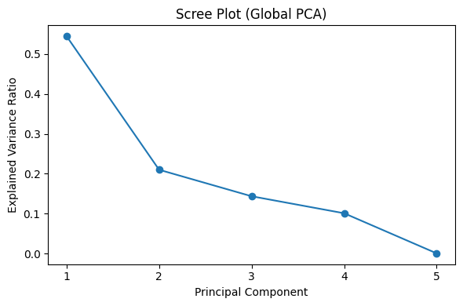

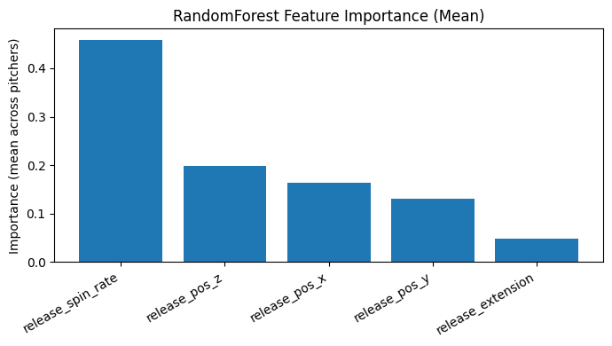

```python
import numpy as np
import matplotlib.pyplot as plt
import pandas as pd

def _get_evr(results):
    evr = results.get("global_pca_explained_variance", None)
    if evr is None:
        raise KeyError("results['global_pca_explained_variance'] not found.")
    # Accept Series or 1-col DataFrame
    if isinstance(evr, pd.Series):
        return evr.values
    if isinstance(evr, pd.DataFrame):
        if evr.shape[1] == 1:
            return evr.iloc[:, 0].values
        # if columns are like ['PC1','PC2',...] treat as row of one record
        if evr.shape[0] == 1:
            return evr.values.ravel()
        # last resort: if there is a column literally named 'explained_variance_ratio'
        if 'explained_variance_ratio' in evr.columns:
            return evr['explained_variance_ratio'].values
    raise ValueError("Unrecognized format for global_pca_explained_variance.")

# 1) Scree plot
def plot_pca_scree(results, figsize=(6,4)):
    evr_vals = _get_evr(results)
    xs = np.arange(1, len(evr_vals)+1)
    plt.figure(figsize=figsize)
    plt.plot(xs, evr_vals, marker="o")
    plt.xticks(xs)
    plt.xlabel("Principal Component")
    plt.ylabel("Explained Variance Ratio")
    plt.title("Scree Plot (Global PCA)")
    plt.tight_layout()
    plt.show()


# 4) Mean RF feature importance
def plot_mean_rf_feature_importance(results, figsize=(7,4)):
    s = results.get("mean_rf_feature_importance", None)
    if s is None:
        raise KeyError("results['mean_rf_feature_importance'] not found.")
    if isinstance(s, pd.DataFrame):
        # if you accidentally stored a 1-row DF, flatten
        s = s.iloc[0]
    plt.figure(figsize=figsize)
    plt.bar(s.index, s.values)
    plt.ylabel("Importance (mean across pitchers)")
    plt.title("RandomForest Feature Importance (Mean)")
    plt.xticks(rotation=30, ha="right")
    plt.tight_layout()
    plt.show()
plot_pca_scree(results)
plot_mean_rf_feature_importance(results)
```

As expected we can see that spin rate is the most telling attribute of a given pitch. That is expected as it is the only feature we included that definitly effects the pitch profile. In real application this should be removed as it is not a feature of the pitch profile, but a feature of the pitch iteself.